# Course Project: Demonstrations of the central limit theorem and using the t distribution in hypothesis testing

Vineet W. Singh

19 February 2018

## Introduction

Part 1 of this project, briefly demonstrates the central limit theorem and the law of large numbers at work while using about 1000 samples.

Part 2 demonstrates the use of the t distribution in finding confidence intervals for a two sets of data of about 30 observations each.

### Part 1

This part demonstrates the law of large numbers and the central limit theorem. The law of large numbers states that given enough observations, any statistics generated from those observations will estimate the pouplation statistics with some accuracy.

For example, given a data set with a large number of observations/sampling units, that has been collected from a population that is exponentially distibuted and which has a certain rate parameter(lambda), then the theoretical population mean is supposed to be equal to 1/lambda and the theoretical standard deviation of the mean is also supposed to be equal to 1/lambda.

In this chunk of R code, we randomly generate 1000 observations from an exponential distribution with a rate parameter of 0.2.

```r
mexp<-rexp(1000,0.2)
```

The mean of this particular sample of 1000 observations is:

```r
print(mean(mexp))
```

```
## [1] 5.102263
```

The theoretical mean of the original population that follows the exponential distribution is 1/lambda= 1/0.2 = 5.

As demonstrated, the mean from the randomly generated set is quite close to that of the population mean and can be taken to be a fair/close estimate of the population mean.

A histogram with the original distribution values and the theoretical mean, sample mean is displayed below:

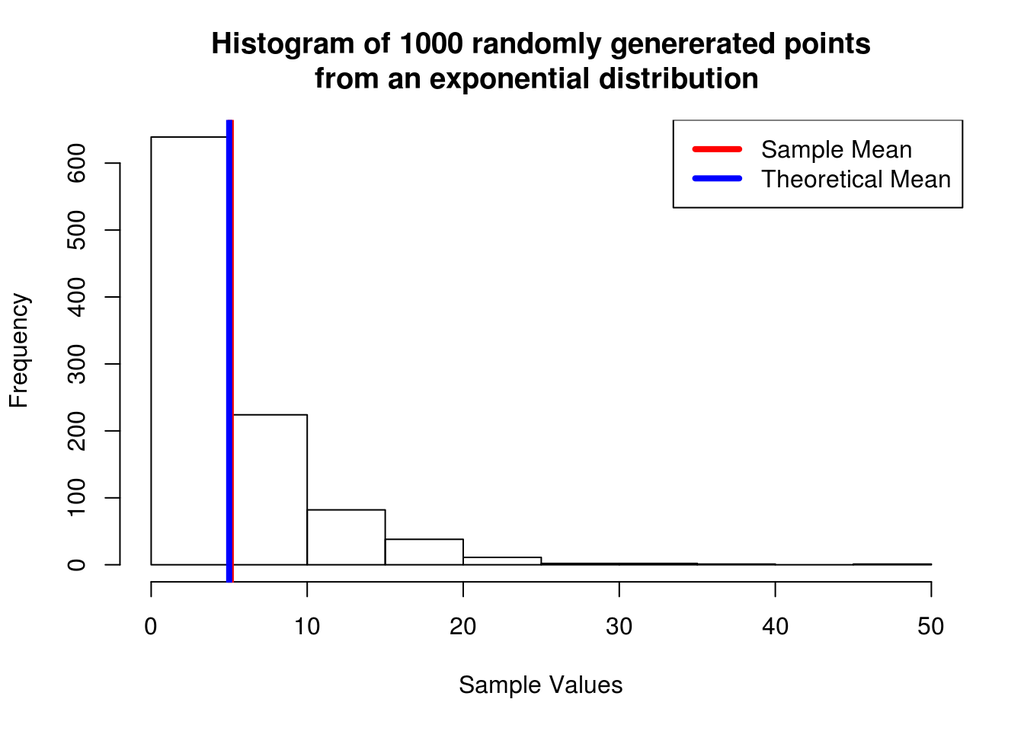

```r
hist(mexp, main=paste0("Histogram of 1000 randomly genererated points\n",
                        "from an exponential distribution "),
     xlab="Sample Values")
abline(v=mean(mexp),col=2,lwd=4)
abline(v=5,col=4,lwd=4)
legend("topright", c("Sample Mean","Theoretical Mean"), col=c(2,4), lwd=4)
```

The central limit theorem states that the means of a large number of samples will be normally distributed around the theoretical population mean.

To demonstrate this we first generate 1000 samples of 1000 observations, randomly taken from the exponential distribution with a population rate parameter(lambda) of 0.2.

As demonstrated above the population mean in supposed to be 5 and the standard deviation of the population mean is also supposed to be 5.

```r
#mns is a list containing 1000 mean values of 1000 observations randomly
#generated from a exponential distribution
mns=NULL
#sds is a list containing 1000 standard deviation of mean of 1000 observations
#randomly generated from the same data as above.
sds=NULL
for (i in 1 : 1000){
x<-rexp(1000,0.2)
mns=c(mns,mean(x))
sds=c(sds,sd(x))
}
```

We can now plot a simple histogram to observe how the actual means from the 1000 samples are distributed. The theoretical population mean is demonstrated as a vertical red line:

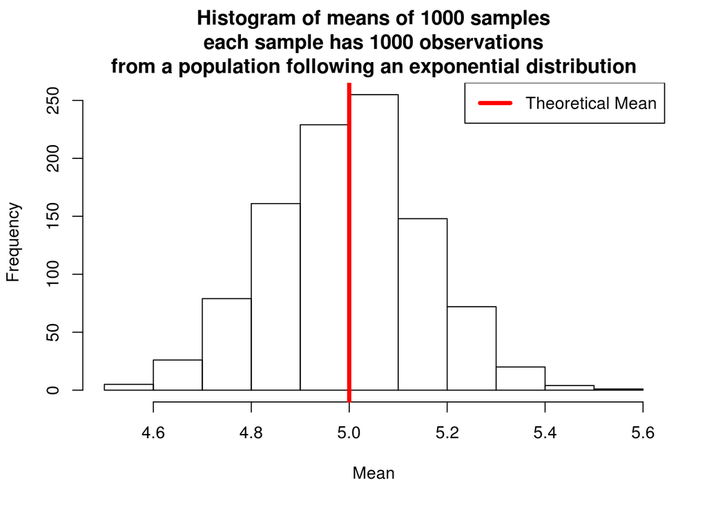

```r
hist(mns, main=paste0("Histogram of means of 1000 samples\n",
                       "each sample has 1000 observations\n",
                    "from a population following an exponential distribution"),
     xlab="Mean")
abline(v=5,col=2,lwd=4)
legend("topright", "Theoretical Mean", col=2, lwd=4)
```

As can be seen from the histogram above, the generated distribution is fairly symmetrical around the theoretical population mean.

Further, there are two ways to demonstrate that the sample means are normally distributed.

One is to convert the frequencies of the means into probabilities and plot this data as a histogram and superimpose onto this histogram, a density line representing probability density:

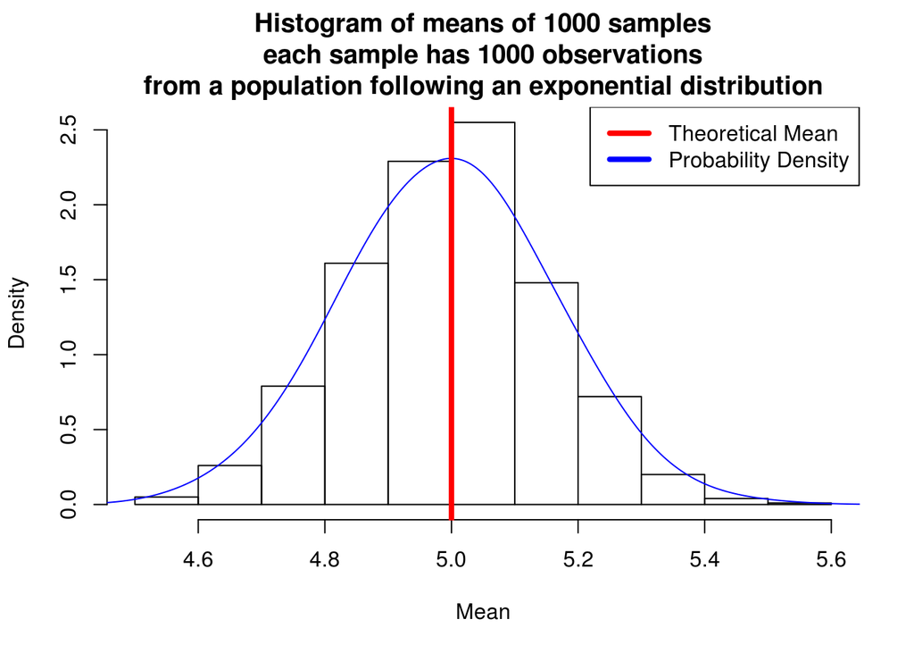

```r
hist(mns, main=paste0("Histogram of means of 1000 samples\n",
                       "each sample has 1000 observations\n",
                    "from a population following an exponential distribution"),
     xlab="Mean",
     probability = TRUE)
lines(density(mns,adjust=2),col=4)
abline(v=5,col=2,lwd=4)
legend("topright", c("Theoretical Mean","Probability Density"),col=c(2,4),lwd=4)
```

Another way is to use the qqnorm function to generate a log normal plot of the data. If the plot points fall on a straight line the data follows a normal distribution.

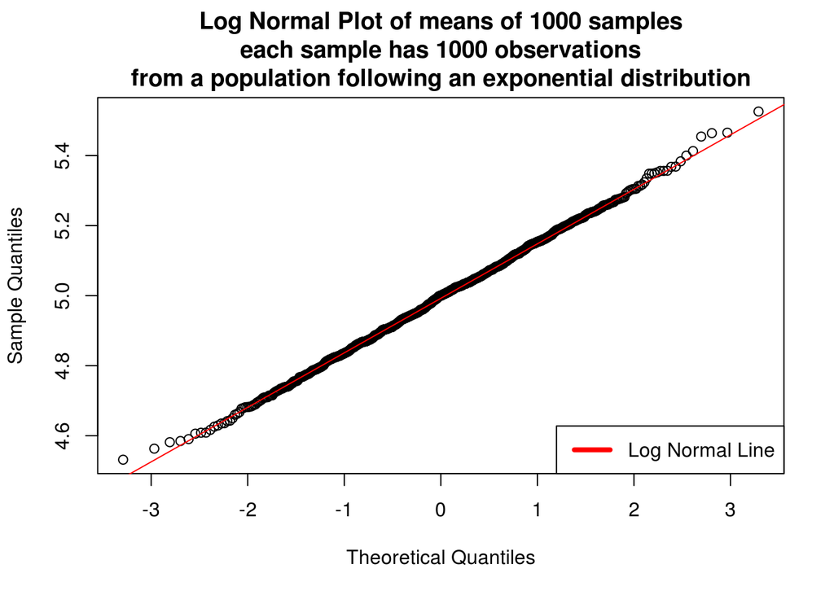

```r
qqnorm(mns, main=paste0("Log Normal Plot of means of 1000 samples\n",
                       "each sample has 1000 observations\n",
                    "from a population following an exponential distribution"))
qqline(mns,col=2)
legend("bottomright", "Log Normal Line",col=2,lwd=4)
```

Similarly we can prove that the standard deviations also are normally distributed by

1. Showing that the standard deviations are symmetrerical around the population SD.

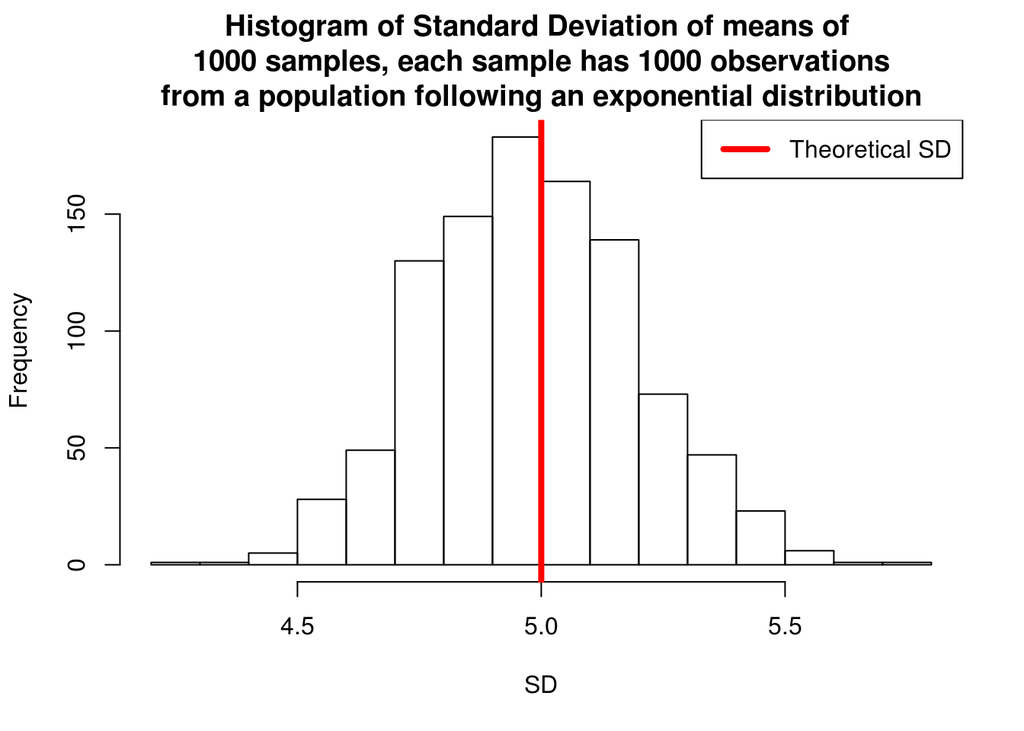

```r
hist(sds, main=paste0("Histogram of Standard Deviation of means of \n",
                       "1000 samples, each sample has 1000 observations\n",
                    "from a population following an exponential distribution"),
     xlab="SD")
abline(v=5,col=2,lwd=4)
legend("topright", "Theoretical SD", col=2, lwd=4)
```

and

2. By plotting the log normal plot of the SD values.

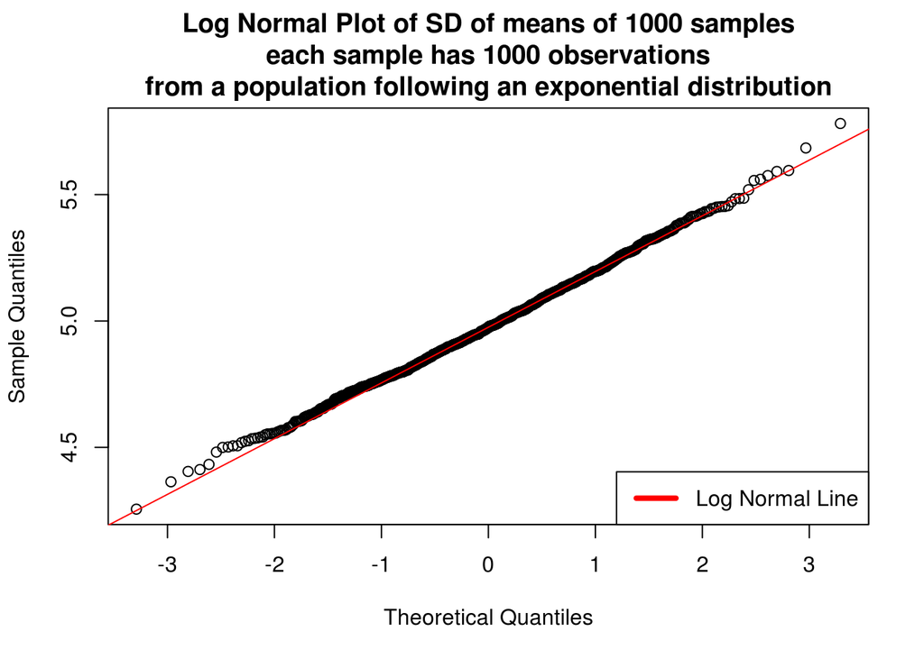

```r
qqnorm(sds, main=paste0("Log Normal Plot of SD of means of 1000 samples\n",
                       "each sample has 1000 observations\n",
                    "from a population following an exponential distribution"))
qqline(sds,col=2)
legend("bottomright", "Log Normal Line",col=2,lwd=4)
```

### Conclusion

We have shown as to how the central limit theorem is satisfied for both the mean and the standard deviation of simulated 1000 samples. The original population is exponentially distributed but the means and SD’s of all samples generated from this exponential distribution follow a normal distribution centered at the population mean and SD respectively.

## Part 2

Part 2 of this project demostrates the use of use of the t distribution to generate confidence intervals and t values to do hypothesis testing based on the ToothGrowth data set that is a part of the datasets library in R.

We hope to answer the following questions after analysing the data:

1. Do the teeth grow the same, for all dosage of supplements or do different doses of supplements result in different growth.
2. Do both the supplements result in the same rate of growth of teeth or is the growth rate different for each supplement.

The tooth growth data set contains data regarding Vitamin C given as a supplement and the resulting growth in teeth of 60 guinea pigs. More information about the dataset can be found at: https://stat.ethz.ch/R-manual/R-devel/library/datasets/html/ToothGrowth.html

### Analysis

To begin the analysis the dplyr and datasets packages are loaded using the library command. This automatically loads the tooth growth data into R.

```r
library(datasets)
library(dplyr)
```

The structure of the ToothGrowth dataset can be found using the str function.

```r
str(ToothGrowth)
```

```
## 'data.frame':    60 obs. of  3 variables:
##  $ len : num  4.2 11.5 7.3 5.8 6.4 10 11.2 11.2 5.2 7 ...
##  $ supp: Factor w/ 2 levels "OJ","VC": 2 2 2 2 2 2 2 2 2 2 ...
##  $ dose: num  0.5 0.5 0.5 0.5 0.5 0.5 0.5 0.5 0.5 0.5 ...
```

We need to partition this set according to the supplements concerned, either “VC” for Ascorbic Acid or “OJ” for orange juice. The resultant datasets are stored in different frames.

We also need to add a new variable “rate” which will measure the rate at which the teeth have grown according to the amount of supplement given. In effect, we are normalising the length with respect to the dose.

```r
tg1 <- ToothGrowth %>% filter(supp=="VC")
tg1<-tg1 %>% mutate(rate=len/dose)
tg2 <- ToothGrowth %>% filter(supp=="OJ")
tg2<-tg2 %>% mutate(rate=len/dose)
```

We can also generate some statistics for each supplement group.

```r
#calculate summaries for each sub group of the two groups
tg1 %>% group_by(dose) %>% summarise(mean=mean(rate),sd=sd(rate),n=n())
```

```
## # A tibble: 3 x 4
##    dose  mean    sd     n
##   <dbl> <dbl> <dbl> <int>
## 1 0.500  16.0  5.49    10
## 2 1.00   16.8  2.52    10
## 3 2.00   13.1  2.40    10
```

```r
tg2 %>% group_by(dose) %>% summarise(mean=mean(rate),sd=sd(rate),n=n())
```

```
## # A tibble: 3 x 4
##    dose  mean    sd     n
##   <dbl> <dbl> <dbl> <int>
## 1 0.500  26.5  8.92    10
## 2 1.00   22.7  3.91    10
## 3 2.00   13.0  1.33    10
```

The growth rates according to the supplement type and dosage groups are:

#### Ascorbic Acid : Summary

| Dose(mg/day) | Mean | SD |
| --- | --- | --- |
| 0.5 | 16 | 5.49 |
| 1 | 16.8 | 2.52 |
| 2 | 13.1 | 2.40 |

#### Orange Juice : Summary

| Dose(mg/day) | Mean | SD |
| --- | --- | --- |
| 0.5 | 26.5 | 8.92 |
| 1 | 22.7 | 3.91 |
| 2 | 13 | 1.33 |

We can draw a plot of the growth rates according to the supplement types.

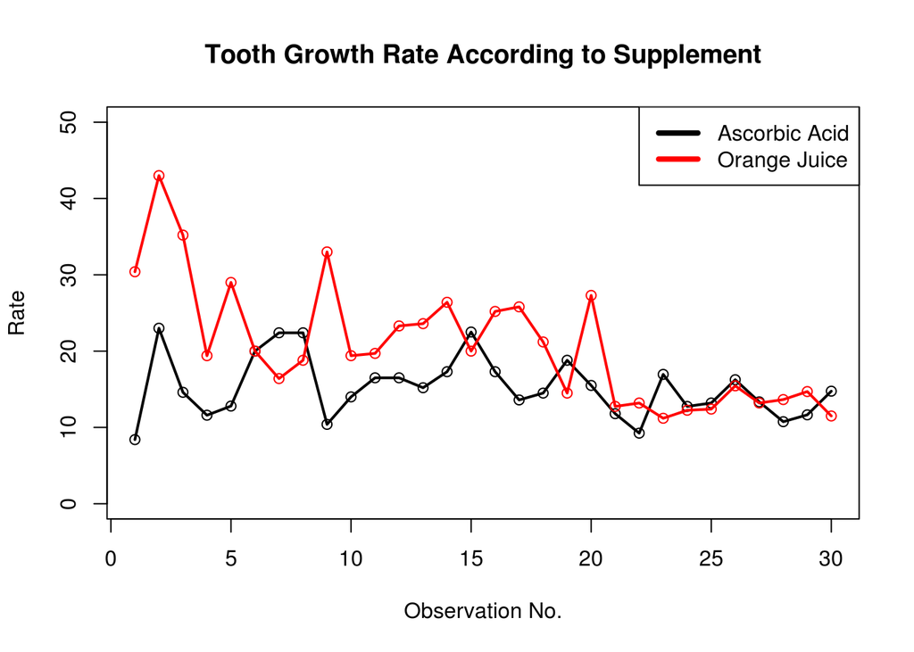

```r
plot(x=row.names(tg1),y=tg1$rate,type="p",pch=1,ylab="Rate",
     main="Tooth Growth Rate According to Supplement",
     xlab="Observation No.", ylim=c(0,50),col=1)
lines(x=row.names(tg1),y=tg1$rate,type="l",lty=1,lwd=2,col=1)
points(x=row.names(tg2),y=tg2$rate,pch=1,col=2)
lines(x=row.names(tg2),y=tg2$rate,type="l",lty=1,lwd=2,col=2)
legend("topright", c("Ascorbic Acid","Orange Juice"),col=c(1,2),lwd=4)
```

From this preliminary analysis, we can observe that the growth rates for both supplements are different. Within each supplement group the growth rates vary according to dosages of supplement given, with the maximum variabilty in the 0.5 mg group for both supplements.

But to get detailed answers we will need to formulate some hypothesis and carry out some tests.

We will need to make some assumptions about the data before we carry out the tests.

We can assume that the growth rate in each animal in each subgroup is independent since each animal is different. Further more we can assume that the variance within each of the 6 subgroups (supplement & dosage) is the same.

However, it is probably not very wise to assume that the variance accross different subgroups is the same as, clearly the dosage levels are different across each subgroup in one supplement group.

The first null hypothesis we propose is:

#### Null Hypothesis No. 1

Mean growth rates for the 0.5(mg/day) group and the 1(mg/day) group of the ascorbic acid set are the same.

To assist us in our analysis we divide the data up further into three groups for each supplement type.

```r
tg11<- tg1 %>% filter(dose==0.5)
tg12<- tg1 %>% filter(dose==1)
tg13<- tg1 %>% filter(dose==2)

tg21<- tg2 %>% filter(dose==0.5)
tg22<- tg2 %>% filter(dose==1)
tg23<- tg2 %>% filter(dose==2)
```

Since we only have 10 measurements each subgroup, we need to make confidence intervals and do tests using the t distribution. This is done using the following command:

```r
t.test(tg11$rate,tg12$rate,paired=F,var.equal = F)
```

```
##
##  Welch Two Sample t-test
##
## data:  tg11$rate and tg12$rate
## t = -0.42396, df = 12.615, p-value = 0.6787
## alternative hypothesis: true difference in means is not equal to 0
## 95 percent confidence interval:
##  -4.950377  3.330377
## sample estimates:
## mean of x mean of y
##     15.96     16.77
```

The t-value is -0.42396, p-value is above .50 and the confidence interval for the difference of means  
contains 0.

**We cannot, therefore, reject null hypothesis no. 1.**

We can assume that the mean growth rates for both 0.5 (mg/day) and 1 (mg/day) dose groups of the ascorbic acid supplement set are the same.

The next null hypothesis we propose is:

#### Null Hypothesis No. 2

Mean growth rates for the 1(mg/day) group and the 2(mg/day) group of the ascorbic acid set are the same.

We test using the t.test function as outlined above:

```r
t.test(tg12$rate,tg13$rate,paired=F,var.equal = F)
```

```
##
##  Welch Two Sample t-test
##
## data:  tg12$rate and tg13$rate
## t = 3.3662, df = 17.96, p-value = 0.003448
## alternative hypothesis: true difference in means is not equal to 0
## 95 percent confidence interval:
##  1.390398 6.009602
## sample estimates:
## mean of x mean of y
##     16.77     13.07
```

We propose the following hypotheses:

#### Null hypothesis No. 3:

Mean growth rates for the 0.5(mg/day) group and the 1(mg/day) group of the orange juice set are the same.

#### Null hypothesis No. 4

Mean growth rates for the 1(mg/day) group and the 2(mg/day) group of the orange juice set are the same.

```r
t.test(tg21$rate,tg22$rate,paired=F,var.equal = F)
```

```
##
##  Welch Two Sample t-test
##
## data:  tg21$rate and tg22$rate
## t = 1.2209, df = 12.337, p-value = 0.245
## alternative hypothesis: true difference in means is not equal to 0
## 95 percent confidence interval:
##  -2.93001 10.45001
## sample estimates:
## mean of x mean of y
##     26.46     22.70
```

```r
t.test(tg22$rate,tg23$rate,paired=F,var.equal = F)
```

```
##
##  Welch Two Sample t-test
##
## data:  tg22$rate and tg23$rate
## t = 7.404, df = 11.047, p-value = 1.321e-05
## alternative hypothesis: true difference in means is not equal to 0
## 95 percent confidence interval:
##   6.796869 12.543131
## sample estimates:
## mean of x mean of y
##     22.70     13.03
```

With the test number three, we find that the t-value is above 1 but not very high, the confidence interval of the difference contains 0 so we cannot rule out that the means might not be the same. Results of test number 4 tell a different story, however, the t-value is very large, the p-value is negligible and the confidence interval of the difference does not contain 0.

**We cannot, therefore, reject null hypothesis no. 3, but using the argument in the sentence above, we can reject null hypothesis no. 4.**

Based on the results of the 4 hypothesis tests above, we should merge the two groups of 0.5(mg/day) and 1(mg/day) for each of the two supplement types. and then do a comparision of the two supplement types based on two groups for each of the supplement type 0.5-1(mg/day) and 2(mg/day).

```r
#CI for mean growth rate for tg11 and tg12 includes 0 so we cannot rule out
#that the mean growth rate for both tg21 and tg22 can be the same
#it might make sense to group tg11 and tg12 together and assume a common mean
#growth rate.

#merge tg21 and tg22 into one frame
tg11<-rbind(tg11,tg12)

#reassign tg23 to tg22
tg12<-tg13

#CI for mean growth rate for tg21 and tg22 includes 0 so we cannot rule out
#that the mean growth rate for both tg21 and tg22 can be the same
#it might make sense to group tg21 and tg22 together and assume a common growth
#rate.

#merge tg21 and tg22 into one frame
tg21<-rbind(tg21,tg22)

#reassign tg23 to tg22
tg22<-tg23
```

The new data sets are ready for the final phase of the analysis. Hypothesis tests between the two supplement groups to answer the questions about which supplement type and dose effects growth the most.

#### Null Hypothesis No. 5

There is no difference in the Mean growth rates between 0.5-1 (mg/day) dosage sub-group of the Ascorbic Acid and Orange Juice supplement groups.

```r
#check rates and hypothesis test for groups according to dose & supplement
t.test(tg11$rate,tg21$rate,var.equal=F,paired=F)
```

```
##
##  Welch Two Sample t-test
##
## data:  tg11$rate and tg21$rate
## t = -4.5183, df = 31.083, p-value = 8.455e-05
## alternative hypothesis: true difference in means is not equal to 0
## 95 percent confidence interval:
##  -11.922742  -4.507258
## sample estimates:
## mean of x mean of y
##    16.365    24.580
```

It is clear from the large negative t-value that the means are not the same. The confidence interval does not contain 0 and is entirely negative implying that, according to this test, the average value of tooth growth in the first group (ascorbic acid) will lie below the average value of the tooth growth in the second group (orange juice).

**We can, therefore reject the null hypothesis no. 5**

#### Null Hypothesis No. 6

There is no difference in the Mean growth rates between 2(mg/day) dosage sub-group of the Ascorbic Acid and Orange Juice supplement groups.

```r
#check rates and hypothesis test for groups according to dose & supplement
t.test(tg12$rate,tg22$rate,var.equal=F,paired=F)
```

```
##
##  Welch Two Sample t-test
##
## data:  tg12$rate and tg22$rate
## t = 0.046136, df = 14.04, p-value = 0.9639
## alternative hypothesis: true difference in means is not equal to 0
## 95 percent confidence interval:
##  -1.819035  1.899035
## sample estimates:
## mean of x mean of y
##     13.07     13.03
```

This result is more interesting. As can be seen from the plot, the average tooth growth rate for each supplement type begins to get close to one another once the dosage begins to reach the 2(mg/day) level. The t-value is small and p-value large, The confidence interval of the difference is small and does contain 0. We can conclude that based on evidence provided by this data there is no difference in the mean growth rates of the 2(mg/day) subgroup of each supplement group. **We cannot, therefore, reject null hyposthesis no. 6.**

It would be interesting to make one final test using all of the 30 observations of each supplement group.

We propose:

#### Null hyposthesis no. 7.

There is no difference in the Mean growth rates between the Ascorbic Acid and Orange Juice supplement groups.

```r
#check rates and hypothesis test for groups according to supplement
t.test(tg1$rate,tg2$rate,var.equal=F,paired=F)
```

```
##
##  Welch Two Sample t-test
##
## data:  tg1$rate and tg2$rate
## t = -3.3707, df = 42.61, p-value = 0.001603
## alternative hypothesis: true difference in means is not equal to 0
## 95 percent confidence interval:
##  -8.732894 -2.193773
## sample estimates:
## mean of x mean of y
##  15.26667  20.73000
```

This result shows that overall if we take normalised growth rates for all observations in the two groups, the growth rates for each supplement type is different as the t-value is large, p-value is negligible and the confidence interval of the difference does not contain 0. It is safe to conclude that the mean growth rates for each supplement type is different.

**We can, therefore reject the null hypothesis no. 7**